# Lurie: Shapefile and ggplot2

Joy Payton

3/18/2019

## Get A Shapefile

Geospatial data can be expressed in maps, which can offer amazing levels of data density.

Shapefiles are actually groups of files. You’ll ordinarily find them as data sources from large organizations that can afford ESRI software licenses and use dedicated geographic information systems (GIS) for heavy-duty geographic data work. Government agencies, for example, often use shapefiles. You can read the standard for shapefiles at the [ESRI website](https://www.esri.com/library/whitepapers/pdfs/shapefile.pdf).

Here, we’re going to download a file from the [Chicago open data portal](https://data.cityofchicago.org) and unzip it to a directory with the name of the file.

```r
download.file("https://data.cityofchicago.org/api/geospatial/5jrd-6zik?method=export&format=Shapefile", "../Data/chicago_census_tracts.zip")
unzip("../Data/chicago_census_tracts.zip", exdir = "../Data/chicago_census_tracts")
```

```r
library(rgdal)
chicago_map <- readOGR(dsn = "../Data/chicago_census_tracts", verbose = FALSE)
```

We can explore this object using the Environment pane in RStudio, or we can use commands like `str` (structure) or `head` (show first few rows) to look into this object.

```r
str(chicago_map, max.level = 2)
```

```
## Formal class 'SpatialPolygonsDataFrame' [package "sp"] with 5 slots
##   ..@ data       :'data.frame':  801 obs. of  9 variables:
##   ..@ polygons   :List of 801
##   ..@ plotOrder  : int [1:801] 186 679 788 136 181 514 598 13 212 15 ...
##   ..@ bbox       : num [1:2, 1:2] -87.9 41.6 -87.5 42
##   .. ..- attr(*, "dimnames")=List of 2
##   ..@ proj4string:Formal class 'CRS' [package "sp"] with 1 slot
```

```r
head(chicago_map@data)
```

|  | commarea | commarea_n | countyfp10 | geoid10 | name10 | namelsad10 | notes | statefp10 | tractce10 |
| --- | --- | --- | --- | --- | --- | --- | --- | --- | --- |
| 0 | 44 | 44 | 031 | 17031842400 | 8424 | Census Tract 8424 | NA | 17 | 842400 |
| 1 | 59 | 59 | 031 | 17031840300 | 8403 | Census Tract 8403 | NA | 17 | 840300 |
| 2 | 34 | 34 | 031 | 17031841100 | 8411 | Census Tract 8411 | NA | 17 | 841100 |
| 3 | 31 | 31 | 031 | 17031841200 | 8412 | Census Tract 8412 | NA | 17 | 841200 |
| 4 | 32 | 32 | 031 | 17031839000 | 8390 | Census Tract 8390 | NA | 17 | 839000 |
| 5 | 28 | 28 | 031 | 17031838200 | 8382 | Census Tract 8382 | NA | 17 | 838200 |

The important takeaway:

- `rgdal` will ingest geoJSON or Shapefile data and give you back a “Spatial Polygons Data Frame”
- This object type can be thought of as having two main sections: a **data frame with tabular data** (`@data`), and four elements which together make up **the map** (`@polygons`, `@plotOrder`, `@bbox`, `@proj4string`).

## Make the simplest map possible

We’re going to use [`ggplot2`](https://ggplot2.tidyverse.org/reference/) to create a static map suitable of printing. It’s not going to be the prettiest!

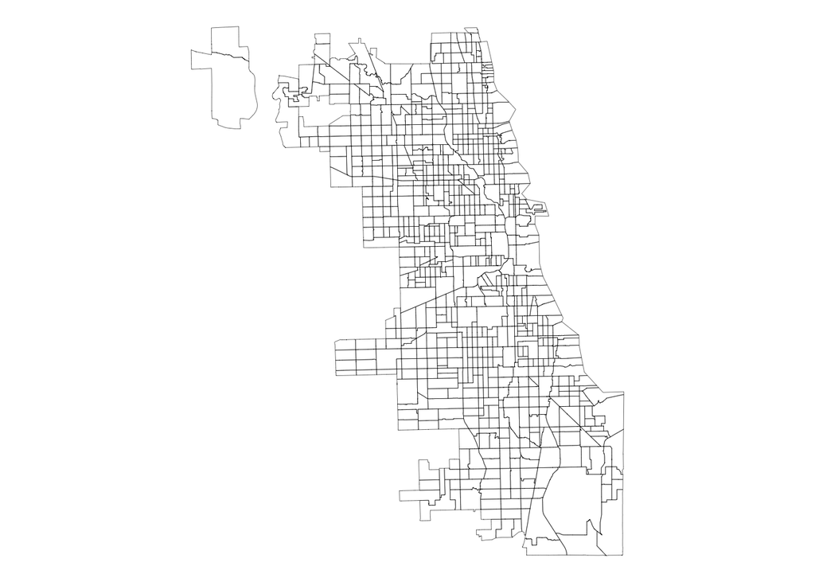

```r
library(ggplot2)
library(ggthemes)
library(broom)
chicago_fortified <- tidy(chicago_map, region = "geoid10")

chicago_plain <- ggplot() +
  geom_polygon(data=chicago_fortified,
               aes(x=long, y=lat, group=group, fill=NA),
               color = "black", fill=NA, size=0.1) +
  coord_map() +
  theme_void()
print(chicago_plain)
```

## Add Our Data!

Currently all we have is a boring map of the Census Tracts in Chicago. Let’s add some data to enrich this map with our own patient or research information.

For the purposes of this exercise, we’re going to use public data from the City of Chicago. See the [download page](https://data.cityofchicago.org/Public-Safety/Crimes-Map/dfnk-7re6) for more details. These are crimes that have taken place in the past year, minus the last seven days. We’ll just look at homicides.

```r
chicago_crimes <- read.csv("https://data.cityofchicago.org/api/views/dfnk-7re6/rows.csv?accessType=DOWNLOAD", stringsAsFactors = FALSE)

library(dplyr)
chicago_homicides <- chicago_crimes %>% filter(PRIMARY.DESCRIPTION == "HOMICIDE")
```

Let’s peek at this data:

```r
head(chicago_homicides)
```

| CASE. | DATE..OF.OCCURRENCE | BLOCK | IUCR | PRIMARY.DESCRIPTION | SECONDARY.DESCRIPTION | LOCATION.DESCRIPTION | ARREST | DOMESTIC | BEAT | WARD | FBI.CD | X.COORDINATE | Y.COORDINATE | LATITUDE | LONGITUDE | LOCATION | Historical.Wards.2003.2015 | Zip.Codes | Community.Areas | Census.Tracts | Wards |
| --- | --- | --- | --- | --- | --- | --- | --- | --- | --- | --- | --- | --- | --- | --- | --- | --- | --- | --- | --- | --- | --- |
| JC113580 | 01/11/2019 10:30:00 PM | 000XX E IDA B WELLS DR | 0110 | HOMICIDE | FIRST DEGREE MURDER | STREET | Y | N | 111 | 4 | 01A | NA | NA | NA | NA |  | NA | NA | NA | NA | NA |
| JC142732 | 02/06/2019 06:45:00 PM | 040XX W GRENSHAW ST | 0110 | HOMICIDE | FIRST DEGREE MURDER | STREET | Y | N | 1132 | 24 | 01A | 1149722 | 1894737 | 41.86707 | -87.72583 | (41.867073203, -87.72582526) | 36 | 21572 | 30 | 98 | 14 |
| JC106397 | 01/06/2019 12:10:00 AM | 014XX W 71ST PL | 0110 | HOMICIDE | FIRST DEGREE MURDER | APARTMENT | N | N | 734 | 17 | 01A | NA | NA | NA | NA |  | NA | NA | NA | NA | NA |
| JC122250 | 01/19/2019 12:18:00 AM | 018XX W 87TH ST | 0110 | HOMICIDE | FIRST DEGREE MURDER | STREET | N | N | 2221 | 21 | 01A | 1165678 | 1846987 | 41.73572 | -87.66860 | (41.735716764, -87.668604253) | 6 | 21554 | 70 | 532 | 13 |
| HZ106402 | 08/30/2018 07:33:00 AM | 005XX S KOSTNER AVE | 0110 | HOMICIDE | FIRST DEGREE MURDER | PARKING LOT | N | N | 1131 | 28 | 01A | 1147140 | 1897299 | 41.87415 | -87.73524 | (41.874153389, -87.735238688) | 36 | 21572 | 27 | 717 | 23 |
| JC196246 | 03/23/2019 03:50:00 AM | 007XX N CLARK ST | 0110 | HOMICIDE | FIRST DEGREE MURDER | STREET | Y | N | 1832 | 2 | 01A | 1175408 | 1905215 | 41.89529 | -87.63121 | (41.895287937, -87.631214259) | 22 | 4446 | 37 | 670 | 11 |

Understanding this data:

- Not every entry has a latitude and longitude. We’re going to limit ourselves just to the rows that do have lat/long data, however.

```r
chicago_homicides <- chicago_homicides %>% filter(!is.na(LATITUDE), !is.na(LONGITUDE))
```

## Mapping Points and Polygons

We could visually overlay shootings on top of the census tracts, which at least helps us see which census tracts might be the most affected. This doesn’t help us calculate any statistics, but at least gives us an intuition about our data:

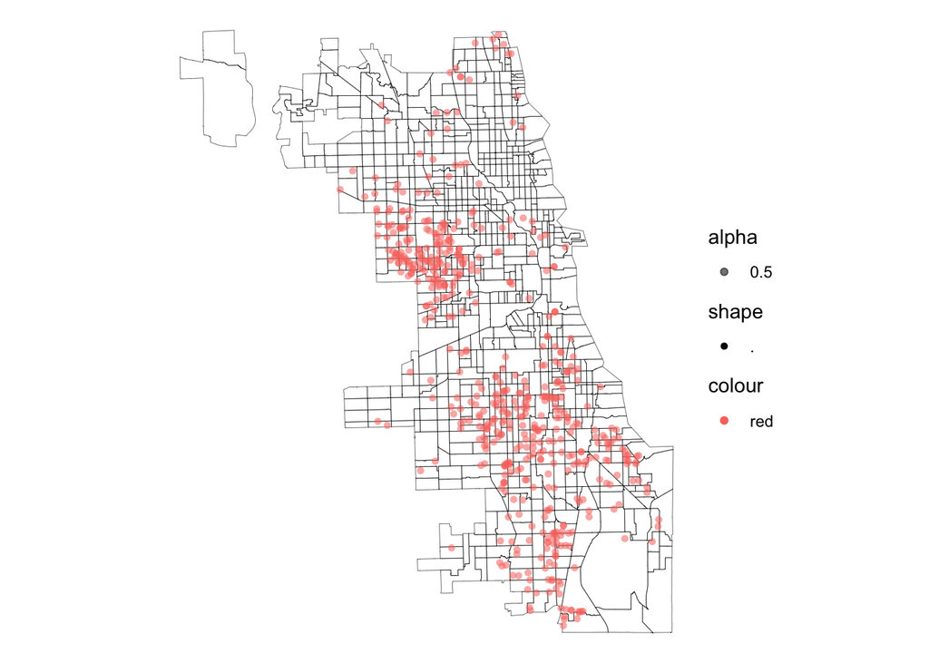

```r
chicago_enhanced <- ggplot() +
  geom_polygon(data=chicago_fortified,
               aes(x=long, y=lat, group=group, fill=NA),
               color = "black", fill=NA, size=0.1) +
  geom_point(data=chicago_homicides, aes(x=LONGITUDE, y=LATITUDE, color="red", shape=".", alpha=0.5)) +
  coord_map() +
  theme_void()
print(chicago_enhanced)
```

From this map, we see that some tracts have no homicides at all, and others have many. We need to remember that not every Census tract has homicide data, and we presume that means that there were 0 homicides, so we will need to add that in, if we want to show data for all Census tracts.

## Mapping Point Data to Polygons

Now what we’d like to do is get the shootings-per-tract data, which we can then combine with our research or clinical data to see if violence near home has any effect on our outcomes. To do this, we take the latitude and longitude of our shootings and transform them slightly so that they are understood as spatial coordinates, not just pairs of numbers. We’ll use the same map projection used in our original `chicago_map`.

```r
library(sp)
coordinates <- SpatialPoints(chicago_homicides[c("LONGITUDE", "LATITUDE")])
proj4string(coordinates) <- proj4string(chicago_map)
```

Let’s now apply what we know about our polygons (from `chicago_map`) and apply that to our points. We’ll end up with a table that has one row for each homicide coordinate. Essentially, what we’re doing is taking each point, lining it up with a matching polygon, and then getting the data about that polygon, which came along with the Shapefile we downloaded.

```r
homicide_tracts <- over(coordinates, chicago_map)
head(homicide_tracts)
```

[output not shown]

```r
homicide_aggregated <- homicide_tracts %>%
  group_by(geoid10) %>%
  summarise(num_homicides = n()) %>%
  ungroup()
head(homicide_aggregated)
```

[output not shown]

```r
non_shooting_tracts <- chicago_map@data %>%
                       select(geoid10) %>%
                       filter(!geoid10 %in% homicide_aggregated$geoid10) %>%
                       mutate(num_homicides = 0)
head(non_shooting_tracts)
```

[output not shown]

```r
homicide_aggregated <- rbind(homicide_aggregated, non_shooting_tracts)
```

## Merging Tabular Data

**WARNING**

`merge` will reorder your rows in a spatial polygon data frame, and that breaks the relationship between the rows of tabular data and the corresponding polygons. In our case, we’re going to combine our homicide aggregate data with `chicago_fortified`, which is *not* a spatial polygon data frame, so we’re safe.

Merging in this case is pretty simple – we just have to bring in the homicide data and make sure our “hinge” (overlapping field) is set up properly:

```r
chicago_fortified <-  merge(x = chicago_fortified,
                 y = homicide_aggregated,
                 by.x = "id",
                 by.y = "geoid10",
                 all = TRUE)
```

## Plot Color-Coded Data (Choropleth)

Let’s see what our homicide numbers look like:

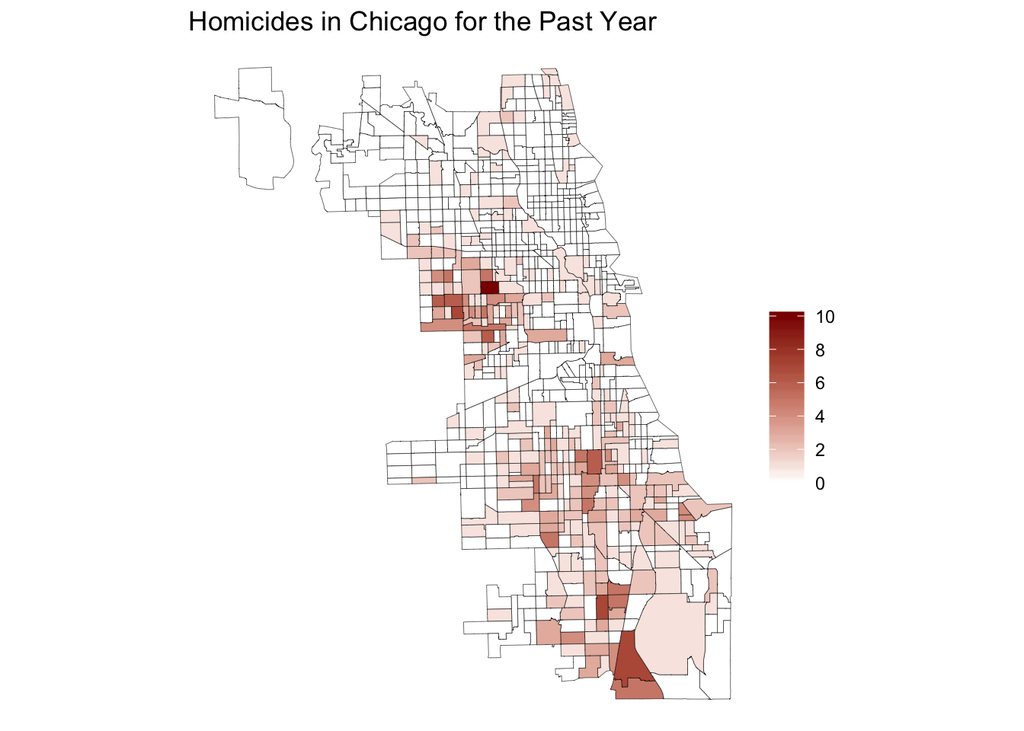

```r
library(scales)
chicago_homicide_map <- ggplot() +
  geom_polygon(data = chicago_fortified, aes(x=long, y=lat, group=group, fill=num_homicides),
               color= "black", size = 0.1)  +
  coord_map() +
  scale_fill_gradient(low = "white", high = "dark red", breaks=pretty_breaks(n=5))  +
  theme_void() +
  labs(title="Homicides in Chicago for the Past Year", fill="")
chicago_homicide_map
```

## Save the Graphic

```r
ggsave("../Media/chicago_homicides.jpg", plot = chicago_homicide_map, device = "jpeg")
```